# **WeRateDog** aren't you a cutie

#### *A look into dog-lover twitter account [WeRateDog](https://twitter.com/dog_rates?ref_src=twsrc%5Egoogle%7Ctwcamp%5Eserp%7Ctwgr%5Eauthor)'s tweets in Nov 2015-Jul 2017*

WeRateDog is a twitter account that post dog pictures and casually "rate" them with witty and funny comments. If you were me, the very thought of "rating a puppy" may sounds uncomfortable. Well, frown not! This unique rating system doesn't serve the purpose of comparing dogs because the majority of our fluffy friend get 10-12 score out of 10 just for being who s/he is.

Take below tweet as an example:

```python
from IPython.display import display
from IPython.display import HTML
import IPython.core.display as di # Example: di.display_html('<h3>%s:</h3>' % str, raw=True)

# This line will hide code by default when the notebook is exported as HTML
di.display_html('<script>jQuery(function() {if (jQuery("body.notebook_app").length == 0) { jQuery(".input_area").toggle(); jQuery(".prompt").toggle();}});</script>', raw=True)


# embedded twitter
class Tweet(object):
    def __init__(self, embed_str=None):
        self.embed_str = embed_str

    def _repr_html_(self):
        return self.embed_str

s = ("""
<blockquote class="twitter-tweet"><p lang="en" dir="ltr">Here&#39;s a doggo realizing you can stand in a pool. 13/10 enlightened af (vid by Tina Conrad) <a href="https://t.co/7wE9LTEXC4">pic.twitter.com/7wE9LTEXC4</a></p>&mdash; WeRateDogs® (@dog_rates) <a href="https://twitter.com/dog_rates/status/744234799360020481?ref_src=twsrc%5Etfw">June 18, 2016</a></blockquote> <script async src="https://platform.twitter.com/widgets.js" charset="utf-8"></script>
""")
Tweet(s)
```

> Here's a doggo realizing you can stand in a pool. 13/10 enlightened af (vid by Tina Conrad) [pic.twitter.com/7wE9LTEXC4](https://t.co/7wE9LTEXC4)

> — WeRateDogs® (@dog_rates) [June 18, 2016](https://twitter.com/dog_rates/status/744234799360020481?ref_src=twsrc%5Etfw)

Our fluffy friend here was having an aha moment about standing in the pool, which got 152.9k likes and 76.9k retweets. This post is actually the most favored and retweeted tweets in 2016 from WeRateDog.

With the help of a neural network that can classify breeds of dogs, we learn that Labrador and Golden Retrievers were posted the most by WeRateDog during the whole year 2016 and the first half of 2017, followed by Welsh Corgi (Cardigan and Pembroke) and Chihuahua.

Furthermore, looking at the sources of the tweets, most of them coming from phone tweets (90+%), suggesting phone is the most prevailing methods for people uploading and checking contents on twitter.

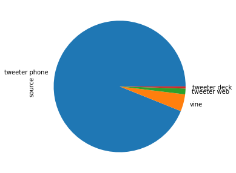